# report

José Ferreira

13 de Março de 2017

# Frequent Pattern Mining and Association Rules

This case study targets the analysis of a dataSet with detailed road safety data provided by the department of transport of the UK government and the purpose is to find interesting rules or patterns on the circumstances of traffic road accidents.

Find the most popular items on the rules, relation between them, rules with high quality values, relation between different measures of interest, etc.

## Pipeline

The work has been divided into 3 phases :

- raw data transformation into transaction data
- itemSet generation and quality assessment
- rule extraction and quality assessment

### raw data transformation into transaction data

This transformation process implies several choices:

- NA elimination
- enforce variable domain
- apply discretization method
- variable selection/filtering

```r
summary(raw)
```

```
##  Accident_Index     Location_Easting_OSGR Location_Northing_OSGR
##  Length:140056      Min.   : 70860        Min.   :  10628
##  Class :character   1st Qu.:385626        1st Qu.: 176638
##  Mode  :character   Median :451460        Median : 240886
##                     Mean   :446914        Mean   : 289904
##                     3rd Qu.:526760        3rd Qu.: 391184
##                     Max.   :655282        Max.   :1197917
##                     NA's   :27            NA's   :27
##    Longitude          Latitude      Police_Force  Accident_Severity
##  Min.   :-7.4229   Min.   :49.92   Min.   : 1.0   Min.   :1.000
##  1st Qu.:-2.2161   1st Qu.:51.48   1st Qu.: 6.0   1st Qu.:3.000
##  Median :-1.2362   Median :52.05   Median :30.0   Median :3.000
##  Mean   :-1.3305   Mean   :52.50   Mean   :29.9   Mean   :2.834
##  3rd Qu.:-0.1725   3rd Qu.:53.41   3rd Qu.:45.0   3rd Qu.:3.000
##  Max.   : 1.7584   Max.   :60.66   Max.   :98.0   Max.   :3.000
##  NA's   :27        NA's   :27
##  Number_of_Vehicles Number_of_Casualties     Date
##  Min.   : 1.000     Min.   : 1.000       Length:140056
##  1st Qu.: 1.000     1st Qu.: 1.000       Class :character
##  Median : 2.000     Median : 1.000       Mode  :character
##  Mean   : 1.841     Mean   : 1.329
##  3rd Qu.: 2.000     3rd Qu.: 1.000
##  Max.   :37.000     Max.   :38.000
##
##   Day_of_Week        Time          Local_Authority_(District)
##  Min.   :1.000   Length:140056     Min.   :  1.0
##  1st Qu.:2.000   Class1:hms        1st Qu.:104.0
##  Median :4.000   Class2:difftime   Median :323.0
##  Mean   :4.095   Mode  :numeric    Mean   :343.6
##  3rd Qu.:6.000                     3rd Qu.:517.0
##  Max.   :7.000                     Max.   :941.0
##
##  Local_Authority_(Highway) 1st_Road_Class  1st_Road_Number
##  Length:140056             Min.   :1.000   Min.   :   0.0
##  Class :character          1st Qu.:3.000   1st Qu.:   0.0
##  Mode  :character          Median :4.000   Median : 118.0
##                            Mean   :4.103   Mean   : 982.3
##                            3rd Qu.:6.000   3rd Qu.: 701.0
##                            Max.   :6.000   Max.   :9914.0
##
```

[output cut: 33 more lines]

```
##  Min.   :-1.00000    Min.   :1.000
##  1st Qu.: 0.00000    1st Qu.:1.000
##  Median : 0.00000    Median :1.000
##  Mean   : 0.06175    Mean   :1.343
##  3rd Qu.: 0.00000    3rd Qu.:2.000
##  Max.   : 7.00000    Max.   :2.000
##
##  Did_Police_Officer_Attend_Scene_of_Accident LSOA_of_Accident_Location
##  Min.   :-1.000                              Length:140056
##  1st Qu.: 1.000                              Class :character
##  Median : 1.000                              Mode  :character
##  Mean   : 1.199
##  3rd Qu.: 1.000
##  Max.   : 3.000
##
```

The following variables were selected from the raw dataframe:

- ‘1st_Road_Class’
- `2nd_Road_Class`
- Road_Type
- Speed_limit
- Weather_Conditions
- Light_Conditions
- Road_Surface_Conditions
- Police_Force
- Accident_Severity
- Number_of_Vehicles
- Number_of_Casualties

```r
summary(transactions)
```

```
## transactions as itemMatrix in sparse format with
##  135520 rows (elements/itemsets/transactions) and
##  80 columns (items) and a density of 0.1375
##
## most frequent items:
##              Accident_Severity=Slight
##                                114437
## Weather_Conditions=Fine no high winds
##                                113883
##                Number_of_Casualties=1
##                                105726
##                           Road_Type=6
##                                101683
##                    Light_Conditions=1
##                                 99756
##                               (Other)
##                                955235
##
## element (itemset/transaction) length distribution:
## sizes
##     11
## 135520
##
##    Min. 1st Qu.  Median    Mean 3rd Qu.    Max.
##      11      11      11      11      11      11
##
## includes extended item information - examples:
##           labels    variables levels
## 1 Police_Force=1 Police_Force      1
## 2 Police_Force=2 Police_Force      2
## 3 Police_Force=3 Police_Force      3
##
## includes extended transaction information - examples:
##   transactionID
## 1             1
## 2             2
## 3             3
```

### itemsets generation

In this phase i’ve decided not to do frequent itemSet analysis on the whole transaction matrix. Instead, i´ve computed a dissimilarity matrix on a 15.000 lenght sample and labled the whole transaction set in 6 clusters.

#### cluster results

```r
summary(silhouette)
```

```
## Silhouette of 15000 units in 6 clusters from silhouette.default(x = clusteringVectors$clustering, dist = diss) :
##  Cluster sizes and average silhouette widths:
##        2968        2852        3249        1529        3082        1320
##  0.19542474  0.03104072 -0.03449425  0.05137553  0.05195761  0.07637781
## Individual silhouette widths:
##     Min.  1st Qu.   Median     Mean  3rd Qu.     Max.
## -0.37450 -0.02153  0.06283  0.05973  0.13150  0.35760
```

```r
summary(c)
```

```
##   Length Class        Mode
## 1 71457  transactions S4
## 2  2990  transactions S4
## 3 12928  transactions S4
## 4 21694  transactions S4
## 5 13067  transactions S4
## 6 13384  transactions S4
```

For each cluster frequent Items, max frequent items, and closed items can be computed with specified support and target(target can be all transactions or individually chosen cluster)

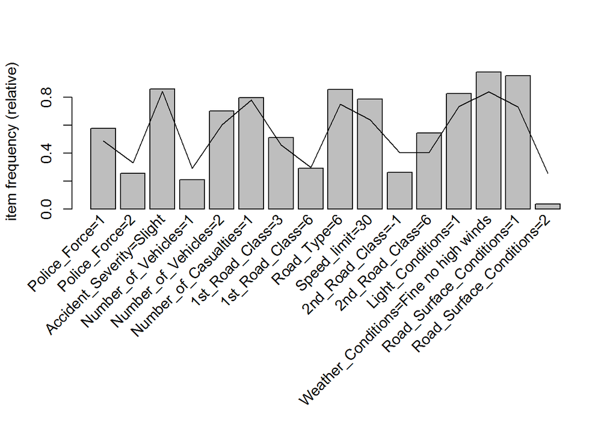

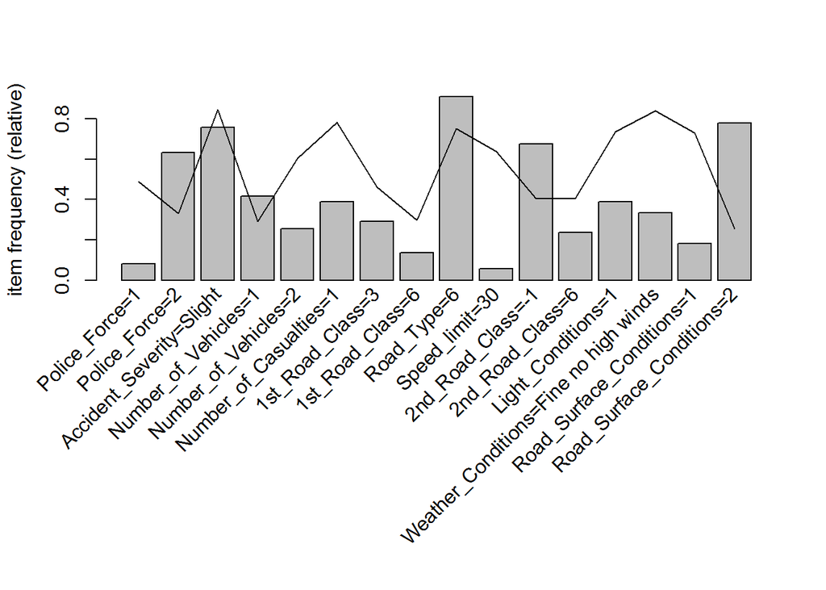

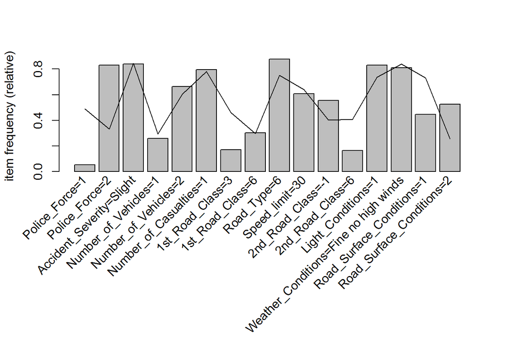

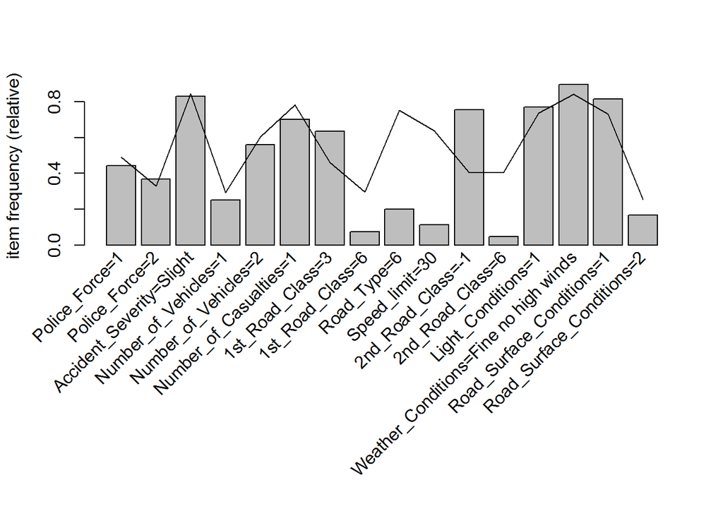

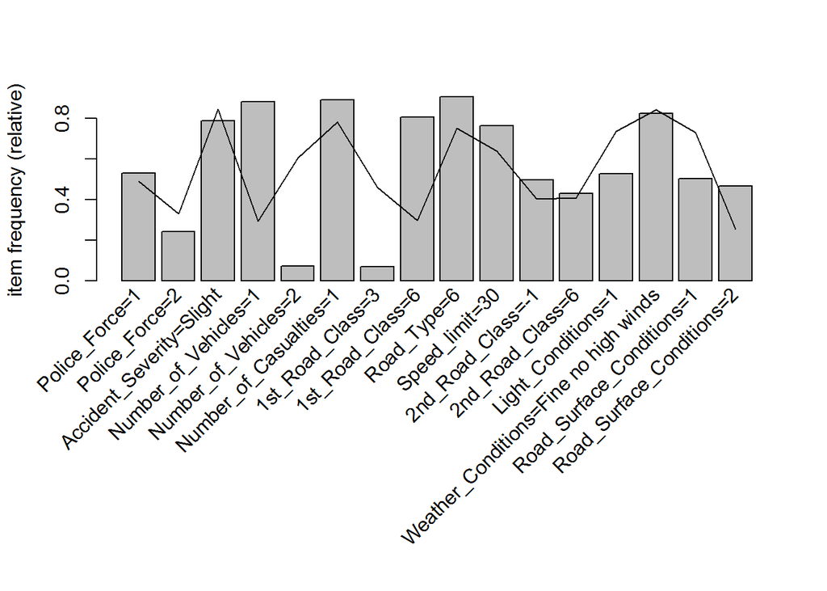

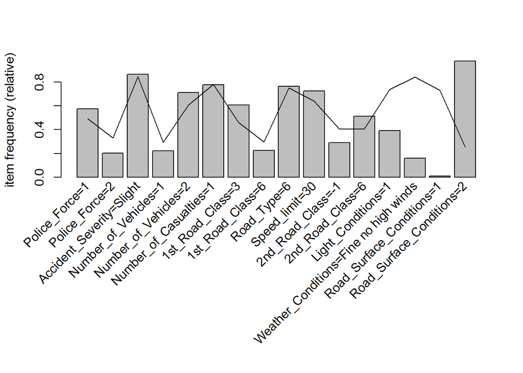

```r
for (i in 1:6)
{
  itemFrequencyPlot(c[[i]], population = transactions, support = 0.2)
}
```

```r
for (i in 1:6)
{
    inspect(head(freqItemsByCluster[[i]],5,by="lift"))
}
```

```
##     items                                     support     lift
## [1] {Road_Type=6,
##      Speed_limit=30,
##      Light_Conditions=1,
##      Weather_Conditions=Fine no high winds,
##      Road_Surface_Conditions=1}             0.5280658 2.439175
## [2] {Number_of_Casualties=1,
##      Road_Type=6,
##      Speed_limit=30,
##      Weather_Conditions=Fine no high winds,
##      Road_Surface_Conditions=1}             0.5318163 2.317788
## [3] {Accident_Severity=Slight,
##      Road_Type=6,
##      Speed_limit=30,
##      Weather_Conditions=Fine no high winds,
##      Road_Surface_Conditions=1}             0.5658788 2.278510
## [4] {Number_of_Casualties=1,
##      Speed_limit=30,
##      Light_Conditions=1,
##      Weather_Conditions=Fine no high winds,
##      Road_Surface_Conditions=1}             0.5063045 2.249227
## [5] {Number_of_Vehicles=2,
##      Speed_limit=30,
##      Weather_Conditions=Fine no high winds,
##      Road_Surface_Conditions=1}             0.5243713 2.211494
##     items                                        support     lift
## [1] {Road_Type=6,
##      Speed_limit=60,
##      Road_Surface_Conditions=2}                0.5408027 20.67660
## [2] {Weather_Conditions=Raining no high winds,
##      Road_Surface_Conditions=2}                0.5060201 17.26990
## [3] {Speed_limit=60,
##      Road_Surface_Conditions=2}                0.5625418 16.13764
## [4] {Road_Type=6,
##      Light_Conditions=6}                       0.5016722 12.98889
## [5] {Road_Type=6,
##      Speed_limit=60,
##      2nd_Road_Class=-1}                        0.5307692 12.84351
##     items                                     support     lift
## [1] {Police_Force=2,
```

[output cut: 44 more lines]

```
##     items                                        support     lift
## [1] {Speed_limit=30,
##      Weather_Conditions=Raining no high winds,
##      Road_Surface_Conditions=2}                0.5123282 27.37325
## [2] {Accident_Severity=Slight,
##      Weather_Conditions=Raining no high winds,
##      Road_Surface_Conditions=2}                0.6218619 25.13350
## [3] {Road_Type=6,
##      Weather_Conditions=Raining no high winds,
##      Road_Surface_Conditions=2}                0.5510311 25.06417
## [4] {Number_of_Casualties=1,
##      Weather_Conditions=Raining no high winds,
##      Road_Surface_Conditions=2}                0.5609683 24.54043
## [5] {Weather_Conditions=Raining no high winds,
##      Road_Surface_Conditions=2}                0.7162283 24.44408
```

### rules extraction

As in the previous process rules were extracted per cluster. The following rules were mined using 0.05 as minSupport,0.5 as minConfidence and with sizes between 2 and 8.

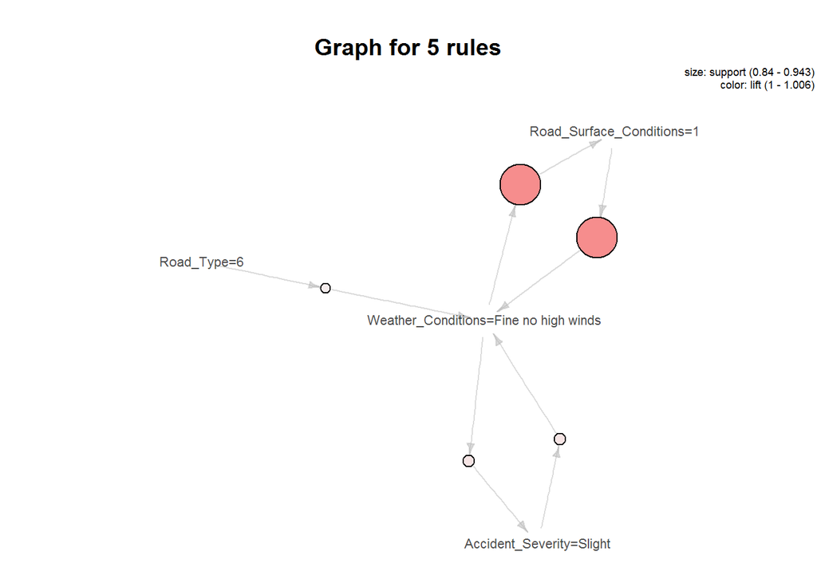

```
##     lhs                                        rhs                   support confidence     lift   improvement
## [1] {Accident_Severity=Slight,
##      2nd_Road_Class=3,
##      Weather_Conditions=Fine no high winds} => {1st_Road_Class=3} 0.07100774  0.7594671 1.482847  1.396128e-04
## [2] {Accident_Severity=Slight,
##      2nd_Road_Class=3}                      => {1st_Road_Class=3} 0.07205732  0.7593275 1.482575  6.518248e-04
## [3] {2nd_Road_Class=3}                      => {1st_Road_Class=3} 0.07985222  0.7586757 1.481302           Inf
## [4] {2nd_Road_Class=3,
##      Weather_Conditions=Fine no high winds} => {1st_Road_Class=3} 0.07870468  0.7586672 1.481285 -8.501758e-06
## [5] {Accident_Severity=Slight,
##      Number_of_Casualties=1,
##      2nd_Road_Class=3,
##      Weather_Conditions=Fine no high winds} => {1st_Road_Class=3} 0.05741915  0.7572905 1.478597 -2.176633e-03
```

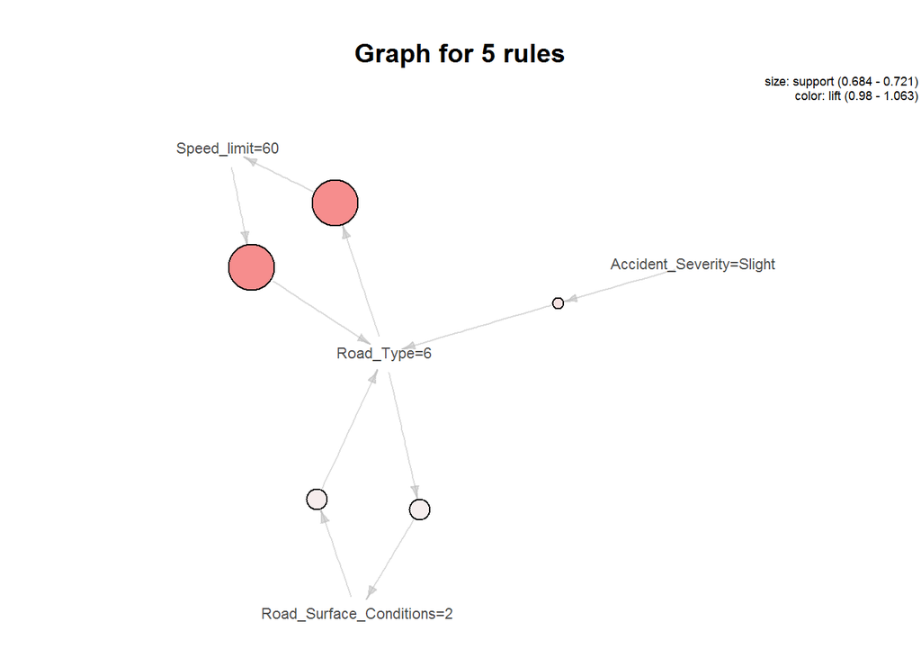

```
##     lhs                                        rhs                            support confidence     lift  improvement
## [1] {Police_Force=2,
##      Number_of_Vehicles=3,
##      Road_Type=6,
##      Weather_Conditions=Fine no high winds} => {Road_Surface_Conditions=1} 0.05317726  0.6463415 3.545983  0.031526649
## [2] {Police_Force=2,
##      Number_of_Vehicles=3,
##      Weather_Conditions=Fine no high winds} => {Road_Surface_Conditions=1} 0.05551839  0.6148148 3.373021  0.066117970
## [3] {Police_Force=2,
##      1st_Road_Class=4,
##      Weather_Conditions=Fine no high winds} => {Road_Surface_Conditions=1} 0.08394649  0.6077482 3.334252  0.059051339
## [4] {Police_Force=2,
##      1st_Road_Class=4,
##      Speed_limit=60,
##      Weather_Conditions=Fine no high winds} => {Road_Surface_Conditions=1} 0.06354515  0.6070288 3.330305 -0.000719430
## [5] {Police_Force=2,
##      1st_Road_Class=4,
##      Road_Type=6,
##      Weather_Conditions=Fine no high winds} => {Road_Surface_Conditions=1} 0.08160535  0.6039604 3.313471 -0.003787788
```

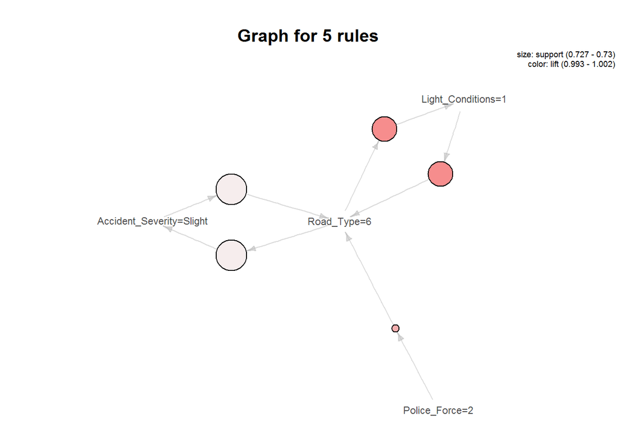

```
##     lhs                            rhs                       support confidence     lift   improvement
## [1] {Police_Force=2,
##      Number_of_Vehicles=2,
##      Road_Type=6,
##      Speed_limit=30,
##      Light_Conditions=1,
##      Road_Surface_Conditions=2} => {2nd_Road_Class=6}     0.05205755  0.5094625 3.099450           Inf
## [2] {2nd_Road_Class=5}          => {1st_Road_Class=5}     0.05399134  0.6724470 2.046950           Inf
## [3] {Police_Force=2,
##      Number_of_Casualties=1,
##      1st_Road_Class=5,
##      2nd_Road_Class=-1}         => {Number_of_Vehicles=1} 0.06211324  0.5197411 2.003343  0.0133308439
## [4] {Road_Type=6,
##      Speed_limit=60,
##      Road_Surface_Conditions=1} => {1st_Road_Class=5}     0.05600248  0.6575840 2.001706  0.0139158923
## [5] {Police_Force=2,
##      Number_of_Casualties=1,
##      1st_Road_Class=5,
##      Road_Type=6,
##      2nd_Road_Class=-1}         => {Number_of_Vehicles=1} 0.06033416  0.5189621 2.000340 -0.0007790245
```

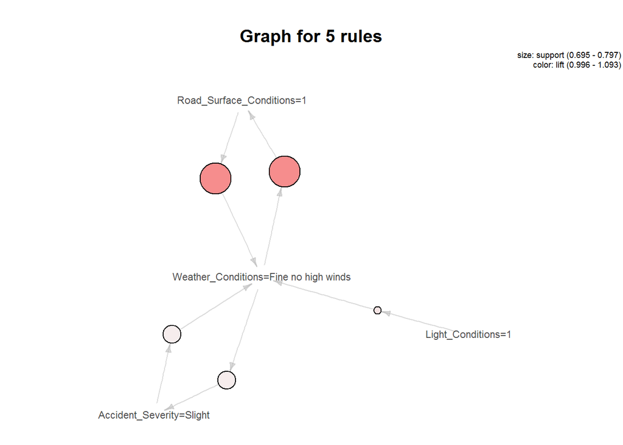

```
##     lhs                                           rhs                            support confidence     lift   improvement
## [1] {Road_Type=3,
##      Weather_Conditions=Raining no high winds} => {Road_Surface_Conditions=2} 0.05218033  0.9488684 5.647394  3.707109e-03
## [2] {Weather_Conditions=Raining no high winds} => {Road_Surface_Conditions=2} 0.05402415  0.9451613 5.625330           Inf
## [3] {Speed_limit=60,
##      2nd_Road_Class=-1,
##      Road_Surface_Conditions=1}                => {Road_Type=6}               0.10804831  0.8729981 4.325907  3.357506e-02
## [4] {Number_of_Casualties=1,
##      Speed_limit=60,
##      2nd_Road_Class=-1,
##      Light_Conditions=1,
##      Road_Surface_Conditions=1}                => {Road_Type=6}               0.06273624  0.8729955 4.325894 -2.627860e-06
## [5] {Speed_limit=60,
##      2nd_Road_Class=-1,
##      Weather_Conditions=Fine no high winds,
##      Road_Surface_Conditions=1}                => {Road_Type=6}               0.10519038  0.8719908 4.320916 -1.007309e-03
```

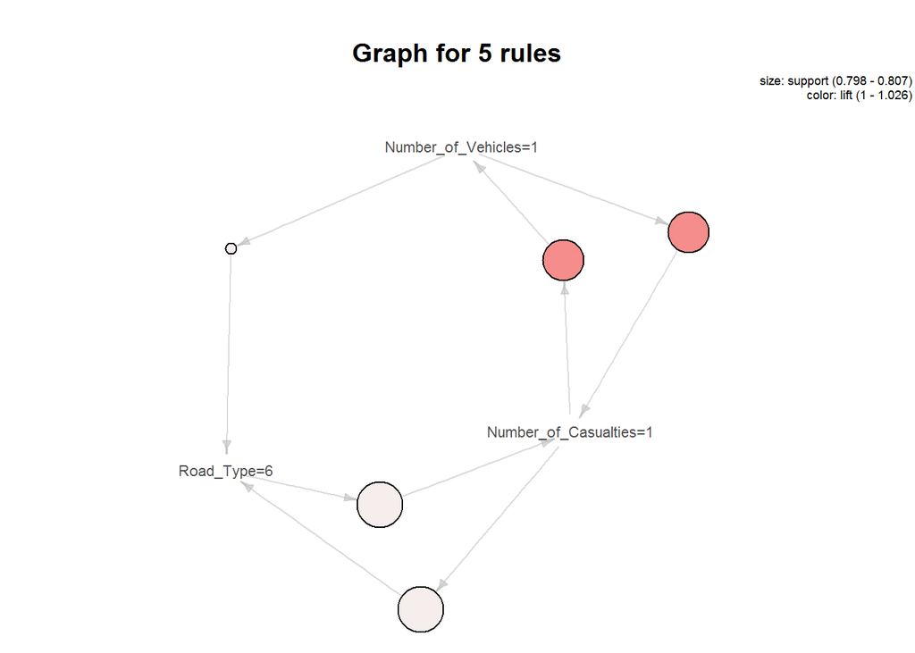

```
##     lhs                                        rhs                     support confidence     lift  improvement
## [1] {Number_of_Vehicles=1,
##      Road_Type=6,
##      Speed_limit=60,
##      Weather_Conditions=Fine no high winds} => {Light_Conditions=6} 0.05150379  0.5253708 5.272673 0.0007439384
## [2] {Road_Type=6,
##      Speed_limit=60,
##      Weather_Conditions=Fine no high winds} => {Light_Conditions=6} 0.05379965  0.5246269 5.265207 0.0060273033
## [3] {Number_of_Vehicles=1,
##      Speed_limit=60,
##      Weather_Conditions=Fine no high winds} => {Light_Conditions=6} 0.05211602  0.5194508 5.213259 0.0008512386
## [4] {Speed_limit=60,
##      Weather_Conditions=Fine no high winds} => {Light_Conditions=6} 0.05441188  0.5185996 5.204716          Inf
## [5] {Number_of_Vehicles=1,
##      Road_Type=6,
##      Light_Conditions=6,
##      Weather_Conditions=Fine no high winds} => {Speed_limit=60}     0.05150379  0.6818642 5.168167 0.0052521080
```

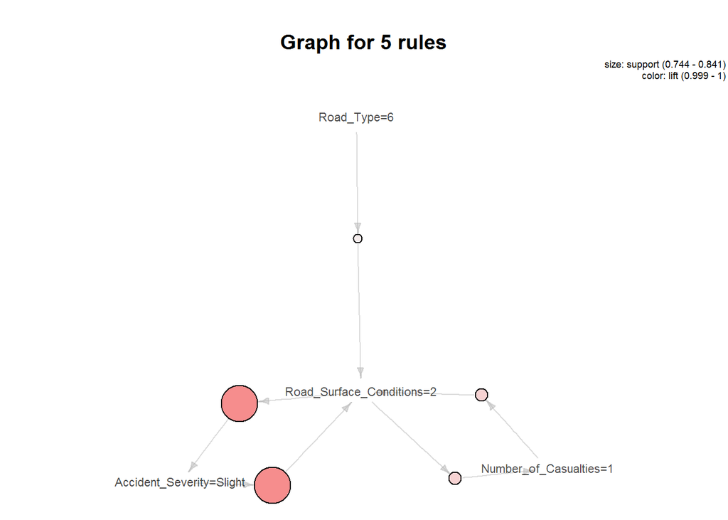

```
##     lhs                                           rhs                       support confidence     lift   improvement
## [1] {Number_of_Casualties=1,
##      1st_Road_Class=3,
##      2nd_Road_Class=-1,
##      Weather_Conditions=Raining no high winds,
##      Road_Surface_Conditions=2}                => {Number_of_Vehicles=1} 0.05267484  0.5276946 2.394124  0.0003277469
## [2] {Number_of_Casualties=1,
##      1st_Road_Class=3,
##      2nd_Road_Class=-1,
##      Weather_Conditions=Raining no high winds} => {Number_of_Vehicles=1} 0.05327256  0.5273669 2.392637           Inf
## [3] {Road_Type=6,
##      Speed_limit=60}                           => {2nd_Road_Class=-1}    0.05289898  0.6327078 2.188721  0.0679928287
## [4] {Road_Type=6,
##      Speed_limit=60,
##      Road_Surface_Conditions=2}                => {2nd_Road_Class=-1}    0.05118051  0.6295956 2.177955 -0.0031121866
## [5] {Speed_limit=60}                           => {2nd_Road_Class=-1}    0.05476689  0.5647149 1.953514           Inf
```

```r
for(i in 1:6)
{
  plot(head(sort(rulesByCluster[[i]] , decreasing = TRUE), 5),method="graph", control=list(cex=.7))
  inspect(head(sort(rulesByCluster[[i]],by="lift"),5))
}
```